# Sub-Pixel : Devoir 4

# Exerice 12

# Question 3

Par définition, $per(u) = u - s$ avec $s$ l'image qui minimise la fonction $F(s) = E(u-s, s) + mean(s)^2$. Cette fonction peut s'écrire comme $(u-s)^TA(u-s) + s^TBs $ avec A, B deux matrices symétriques positives et B définie. En annulant les dérivées en chaque composante de $u$ on obient $s = (A+B)^{-1}Au.$ Ainsi $per(u) = (A+B)^{-1}Bu$. Donc $per(u)$ est bien lineaire, de plus elle est bijective car $(A+B)^{-1}B$ est inversible.

# Question 4

Soit $\lambda \in \mathbb{C}, u \in \mathbb{C}^{\Omega}, u \neq 0$ tels que $per(u) = \lambda u$. Si on reprend la notation de la réponse à la question précédente:$Bu = \lambda(A+B)u$. En multipliant de chaque côté par $\bar{u}^T$ (conjugué transposé): $$\bar{u}^TBu = \lambda \bar{u}^TAu + \lambda \bar{u}^TBu $$ $$\Longleftrightarrow \lambda = \frac{\bar{u}^TBu}{\bar{u}^TAu +\bar{u}^TBu }$$

Or on peut voir que le conjugué de ${\bar{u}^TAu}$ est ${u^TA\bar{u}}$ (en utilisant le fait que A est réelle). Puis en utilisant la symétrie de A :$u^TA\bar{u} = \bar{u}^TAu$. Donc ${\bar{u}^TAu}$ est égal a sa partie réelle. En notant $X, Y$ les parties réelles et imaginaires de u cela s'écrit $$X^TAX + Y^TAY = \bar{u}^TAu$$ Or $A$ est positive donc cette quantité est positive ou nulle. D'où $\bar{u}^TAu \geq 0$.De plus $B$ est définie positive et $X$ ou $Y$ est non nul car $u$ non nul donc $\bar{u}^TBu > 0$.D'où $\lambda \in ]0,1]$.

# Question 5

Soit $u \in \mathbb{R}^{\Omega}$ un point fixe de per. En réutilisant les notations précédentes on a : $Au = 0 \Rightarrow u^TAu = 0$. En revenant a la définition de la matrice A: $$\sum_{x \in \Omega, y \in W(x)} (u(x) - u(y))^2 = 0$$ $$\Longleftrightarrow ∀x \in \Omega , ∀y \in W(x) \quad u(x) = u(y)$$ On peut limiter ces conditions aux $x$ dont $W(x)$ est non vide: $$\Longleftrightarrow ∀x \in \partial{\Omega} , ∀y \in W(x) \quad u(x) = u(y).$$ Réciproquement, on peut remonter les equivalences jusqu'a $u^TAu = 0$, ce qui implique $Au=0$ pour une matrice symétrique positive. En effet si $A$ diagonale : $$u^TAu = 0 ⇔ \sum_i \lambda_i u_i^2 = 0 ⇔\forall i, λ_i\cdot u_i^2 = 0 ⇔ \forall i, λ_i\cdot u_i = 0 ⇔ Au = 0$$ car les $\lambda_i$ sont positifs. Dans le cas général d'une matrice symétrique on peut se ramener à ce cas avec le théorème spectral.

# Question 6

Soit $P$ inversible qui vérifie : $PAP^T=D$ avec $D$ diagonale et $PBP^T=I$. $per$ peut donc s'écrire : $$per = (A+B)^{-1}B = (P^{-1}D{P^T}^{-1}+P^{-1}{P^T}^{-1})^{-1}P^{-1}{P^T}^{-1}$$ $$per={P^T}(D+I)^{-1}PP^{-1}{P^T}^{-1} = {P^T}(D+I)^{-1}{P^T}^{-1}$$ avec $(D+I)^{-1}$ diagonale.

# Exercise 14

# Question 1

```python
import numpy as np
import imtools as im
from math import sin,tan
import matplotlib.pyplot as plt

u = im.load('lena.pgm').astype('double')
x0 = (u.shape[1]+1)/2
y0 = (u.shape[0]+1)/2 # centre de l’image
theta = np.pi/6
u1 = im.fftshear(u, -tan(theta/2), y0, axis=1)
u2 = im.fftshear(u1, sin(theta), x0, axis=0)
u3 = im.fftshear(u2, -tan(theta/2), y0, axis=1)
```

[figure not shown]

```python
plt.imshow(u1, cmap='gray')
```

[figure not shown]

```python
plt.imshow(u2, cmap='gray')
```

[figure not shown]

```python
plt.imshow(u3, cmap='gray')
```

```python
d = np.linspace(-1,1,500)
X,Y = np.meshgrid(d, d)
u = X+Y
x0 = (u.shape[1]+1)/2
y0 = (u.shape[0]+1)/2 # centre de l’image
theta = np.pi/6
u1 = im.fftshear(u, -tan(theta/2), y0, axis=1)
u2 = im.fftshear(u1, sin(theta), x0, axis=0)
u3 = im.fftshear(u2, -tan(theta/2), y0, axis=1)
```

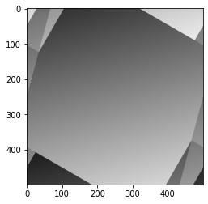

```python
plt.imshow(u3, cmap='gray')
```

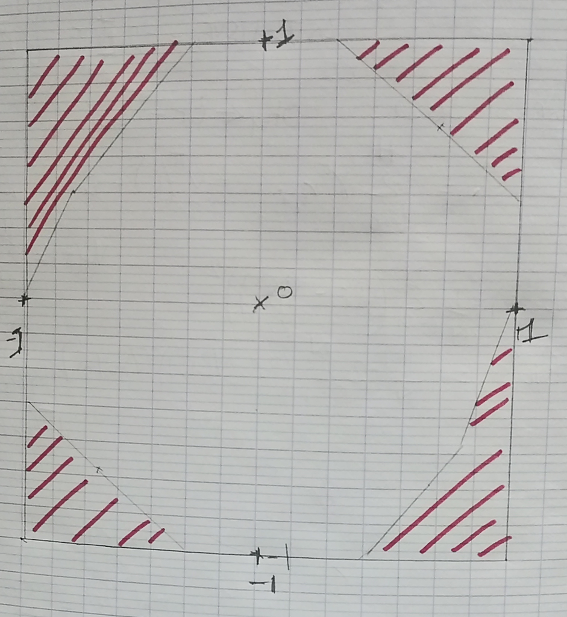

# Question 2

```python
u = im.load('lena.pgm').astype('double')
x0 = (u.shape[1]+1)/2
y0 = (u.shape[0]+1)/2 # centre de l’image
theta = 5*np.pi/6
u1 = im.fftshear(u, -tan(theta/2), y0, axis=1)
u2 = im.fftshear(u1, sin(theta), x0, axis=0)
u3 = im.fftshear(u2, -tan(theta/2), y0, axis=1)
```

[figure not shown]

```python
plt.imshow(u3, cmap='gray')
```

```python
d = np.linspace(-1,1,500)
X,Y = np.meshgrid(d, d)
u = X+Y
x0 = (u.shape[1]+1)/2
y0 = (u.shape[0]+1)/2 # centre de l’image
theta = 5*np.pi/6
u1 = im.fftshear(u, -tan(theta/2), y0, axis=1)
u2 = im.fftshear(u1, sin(theta), x0, axis=0)
u3 = im.fftshear(u2, -tan(theta/2), y0, axis=1)
```

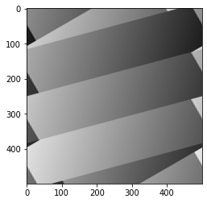

```python
plt.imshow(u3, cmap='gray')
```

On peut voir que pour les rotations d'angle supérieur a $\pi/2$ il y a des morceaux de l'image (sur le domaine où la rotation est sensée être exacte) qui sont mal recollés, par exemple sur l'image tournée de Lena la partie du bas du visage est à la place de celle avec le chapeau et vice versa. </br> Pour un $\theta$ quelconque on peut par exemple décomposer $\theta$ comme un multiple de $\pi/2$ et un reste dans $[0, \pi/2]$, ou comme un multiple de $\pi$ et un reste dans $[-\pi/2, \pi/2]$. En effet on peut réaliser les rotations d'angle multiple de $\pi/2$ de facon exacte car la rotation d'angle $\pi/2$ est dans ce cas une bijection de n'importe quel carré centré dans lui-meme.

```python
u = im.load('lena.pgm').astype('double')
x0 = (u.shape[1]+1)/2
y0 = (u.shape[0]+1)/2 # centre de l’image
theta = np.pi/2
u1 = im.fftshear(u, -tan(theta/2), y0, axis=1)
u2 = im.fftshear(u1, sin(theta), x0, axis=0)
u3 = im.fftshear(u2, -tan(theta/2), y0, axis=1)
u = u3
```

```python
x0 = (u.shape[1]+1)/2
y0 = (u.shape[0]+1)/2 # centre de l’image
theta = np.pi/3
u1 = im.fftshear(u, -tan(theta/2), y0, axis=1)
u2 = im.fftshear(u1, sin(theta), x0, axis=0)
u3 = im.fftshear(u2, -tan(theta/2), y0, axis=1)
```

[figure not shown]

```python
plt.imshow(u3, cmap='gray')
```

# Question 3

En affichant plusieurs rotations d'angle dans $[-\pi/2, \pi/2]$ par produit de glissement d'une image simple il semble que le domaine préservé est le suivant :

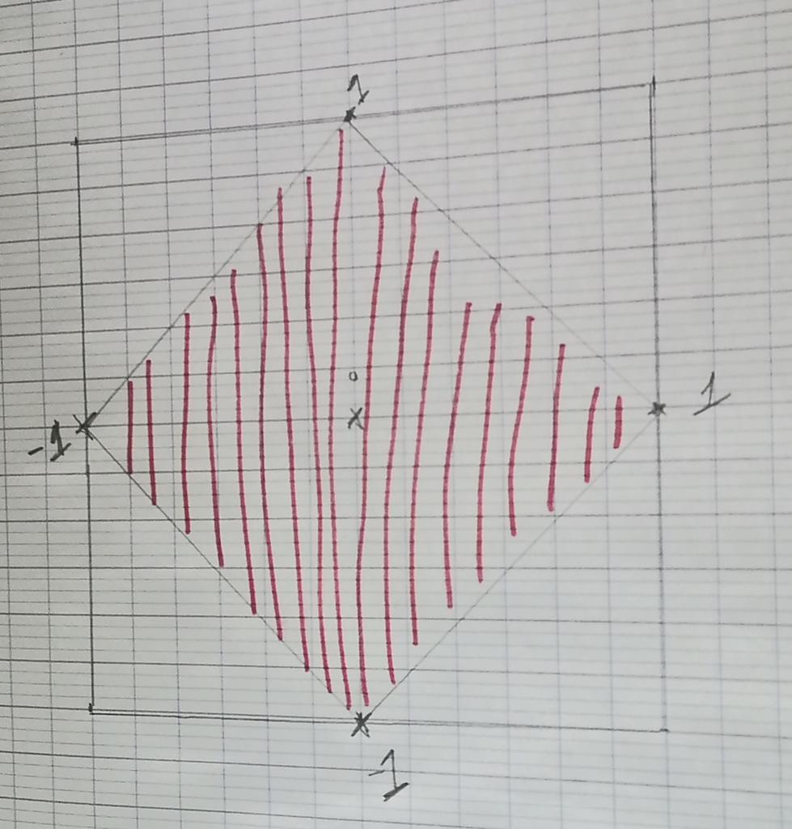